# How to identify points inside and outside the fundamental niche

Laura Jiménez and Carola Franzen

June 2021

## Determine which datapoints are within an ellipse

The function `in.el` creates a matrix that determines how many points are within a confidence region bordered by an ellipse. The ellipse is calculated based on a species’ environmental data and a confidence level. The points inside the ellipse are potential data points of the niche in which a species may thrive.

## Parameters

Four parameters need to be defined for this function:

- `cloud` = a matrix with random points that contain environmental data
- `centroid` = mean of the columns of a matrix that contains environmental data linked with a species’ occurrence
- `sigma` = the covariance of environmental data linked with a species’ occurrence that defines the ellipse
- `alpha` = the confidence level to be used

## How *in.el* works

The function calculates the distance of all points within a cloud. The calculation is based on the Mahalanobis distance. An ellipse is created with the chosen confidence level and defines the confidence region. As a next step, the function checks whether a point lies within the ellipse or not.

```r
in.el <- function(cloud,centroid,sigma,alpha){
  # step 1: calculate de Mahalanobis distance
  maha <- mahalanobis(x=cloud,center=centroid,cov=sigma)
  # step 2: a point is inside the confidence region (1-alpha=confidence%) if
  # the distance divided by the quantile of a Chi-square variable with k d.f. is less than 1
  chi.q <- qchisq(alpha,ncol(cloud))
  check <- (maha/chi.q) <= 1
  cloud <- cbind(rep(1,nrow(cloud))*check,cloud)
    return(as.matrix(cloud))
}
```

### Output

The output is a matrix that contains data on which points lie within an ellipse. This matrix can be visualized with a plot.

## Worked Examples

### Input data

For this function two matrices are necessary: one that uses random points to create a cloud of background points with environmental data and another one that contains the occurrence points of a species in correspondence with environmental data. Both matrices can be created by using the `get.ecoord` function (see tutorial “Function *get.ecoord*”).

### *Threnetes ruckeri*

**Input Files**

- Threnetes_ruckeri_M_GE.csv
- Threnetes_ruckeri_occ_GE.csv

For the random background points in correspondence with environmental data the “M_bios.csv”-file that was created with `get.ecoord` is used.

```r
# read table and omit coordinates
cloud1 <- read.csv("./Generated_Data/Threnetes_ruckeri_M_GE.csv",header=T)[,-(1:2)]
```

For the species’ occurrence points in correspondence with environmental data the “bios.csv”-file that was created with `get.ecoord` is used.

```r
# read table and omit coordinates
thr.occE <- read.csv("./Generated_Data/Threnetes_ruckeri_occ_GE.csv",header=T)[,-(1:2)]
```

The centroid is calculated by taking the means of the two columns in the matrix.

```r
mu1 <- colMeans(thr.occE)
```

Sigma is calculated with covariance of the environmental data of the occurrence points.

```r
Sigma1 <- cov(thr.occE)
```

Apply `in.el` with the parameters `cloud`, `centroid`, `sigma`, and `alpha`. The value for alpha can be set directly in the function. The Mahalanobis distance is calculated with environmental conditions that were linked to presence points of a species. The points within an ellipse reflect theoretical environmental conditions in which a species may thrive. This ellipse can serve as a border for suitable environments.

Plot the matrix of clouds with an ellipse.

```r
# Use the function to determine which points from the matrix are inside the ellipse
check <- in.el(cloud = cloud1, mu = mu1, sigma = Sigma1, 0.95)
```

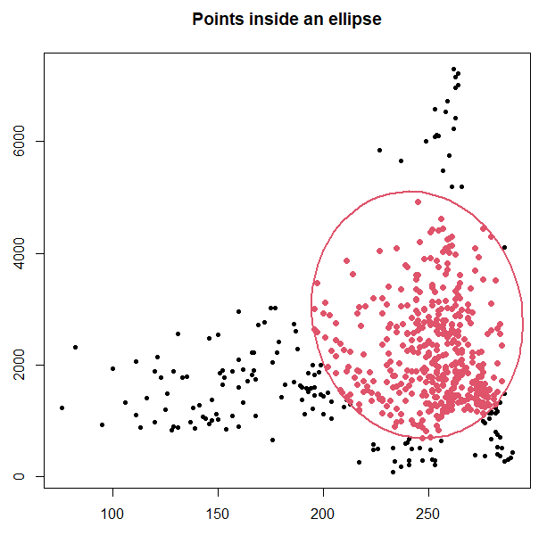

Figure of *Threnetes ruckeri* occurrences in the environmental space delineated by an ellipse.

```r
# plot
# x11()
plot(check[,2],check[,3],pch=20,xlab="",ylab="",main="Points inside an ellipse")
el <- ellipse::ellipse(x=Sigma1, centre = mu1, level=0.95)
lines(el,col=2,lwd=2)
points(subset(check,check[,1]==1)[,2:3],pch=19,col=2)
```

### *Catasticta nimbice*

#### 2D Version

**Input Files**

- Catasticta_nimbice_occ_GE.csv
- Catasticta_nimbice_M_GE.csv

Prepare the parameters `centroid`, `sigma`, and `cloud` and plot.

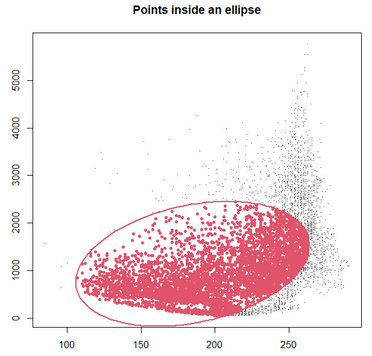

Figure of *Catasticta nimbice* occurrences in the environmental space delineated by an ellipse.

```r
cn.occE <- read.csv ("./Generated_Data/Catasticta_nimbice_occ_GE.csv",header=T)[,-(1:2)]
mu2 <- colMeans(cn.occE)
Sigma2 <- cov(cn.occE)
cloud2 <- read.csv("./Initial_Data/Catasticta_nimbice_M_GE.csv",header=T)[,-(1:2)]

check2 <- in.el(cloud2, mu2, Sigma2, 0.95)

# x11()
plot(check2[,2], check2[,3], pch=".", xlab="", ylab="",
     main="Points inside an ellipse")
el <- ellipse::ellipse(x=Sigma2, centre = mu2, level=0.95)
lines(el, col=2, lwd=2)
points(subset(check2, check2[,1]==1)[,2:3], pch=20, col=2)
```

#### 3D version

**Dependencies:**

- rgl

**Input data:**

- Catasticta_nimbice_occ_GE3.csv
- Catasticta_nimbice_M_GE3.csv

Prepare the parameters `centroid`, `sigma`, and `cloud`.

```r
# read occurrence points with three environmental variables
cn.occE3 <- read.csv ("./Generated_Data/Catasticta_nimbice_occ_GE3.csv",header=T)[,-(1:2)]

mu3 <- colMeans(cn.occE3)
Sigma3 <- cov(cn.occE3)

# Define the matrix of points with matrix of random points that have three
#   environmental layers
cloud3 <- read.csv("./Generated_Data/Catasticta_nimbice_M_GE3.csv",header=T)[,-(1:2)]
```

Apply the function:

```r
check3 <- in.el(cloud = cloud3, centroid = mu3, sigma = Sigma3, alpha = 0.95)
```

Plot in 3D using the package `rgl`:

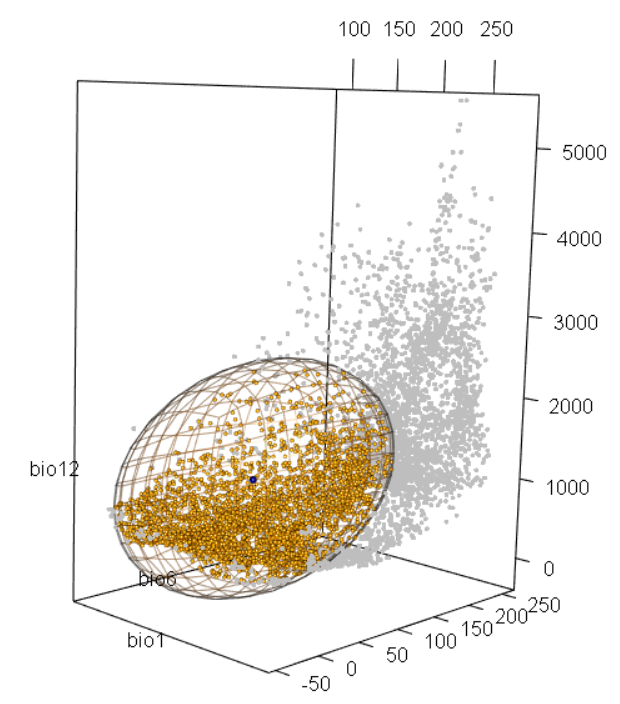

Figure of *Catasticta nimbice* occurrences in the environmental space delineated by an ellipse with three dimensions.

```r
# create the three dimensional ellipse
elli <- ellipse3d(centre = mu3, x= Sigma3, level = 0.95)

open3d()
plot3d(subset(check3,check3[,1]==1)[,2:4], box = FALSE,
       xlab="bio1", ylab="bio6", zlab="bio12", type = "s", size= 0.6,
       col="orange")
points3d(subset(check3,check3[,1]==0)[,2:4], size= 4,
         col= "grey")
spheres3d(x=mu3[1], y=mu3[2], z=mu3[3], radius=25, col="darkblue")
plot3d(elli, col = "darkorange4", alpha = 0.5, add = TRUE, type = "wire")
```

### Theoretical Example

In this example, the data points for the cloud and the centroid are constructed and no input files are needed.

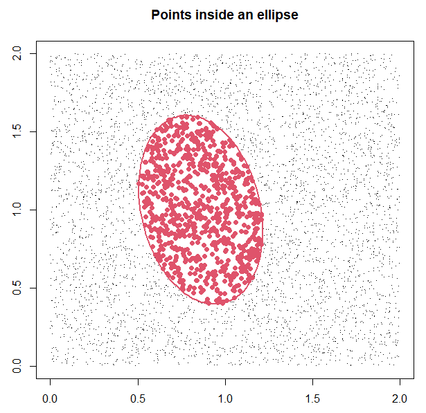

Figure of a cloud with random points and specific points that are within an ellipse

```r
mu <- c(0.86,1)
sigma <- matrix(c(0.021,-0.008,-0.008,0.061),ncol=2,byrow=T)
# Define the matrix of points
cloud <- cbind(runif(5000,0,2),runif(5000,0,2))
# Use the function to determine which points from the matrix are inside the ellipse
check <- in.el(cloud,mu,sigma,0.95)
# Plot the points, ellipse and use different colors for the points inside/outside the ellipse
# x11()
plot(check[,2],check[,3],pch=".",xlab="",ylab="",main="Points inside an ellipse")
el <- ellipse::ellipse(x=sigma,centre = mu,level=0.95)
lines(el,col=2,lwd=2)
points(subset(check,check[,1]==1)[,2:3],pch=19,col=2)
```